# Lab 3 - Trực quan hóa dữ liệu với ggplot2

### Câu 1.

Vẽ một biểu đồ, sử dụng histogram, để mô tả sự phân bố rác thải nhựa trên đầu người theo từng châu lục. Bạn có thể nói gì về sự khác biệt giữa các châu lục về lượng rác thải nhựa trên đầu người?

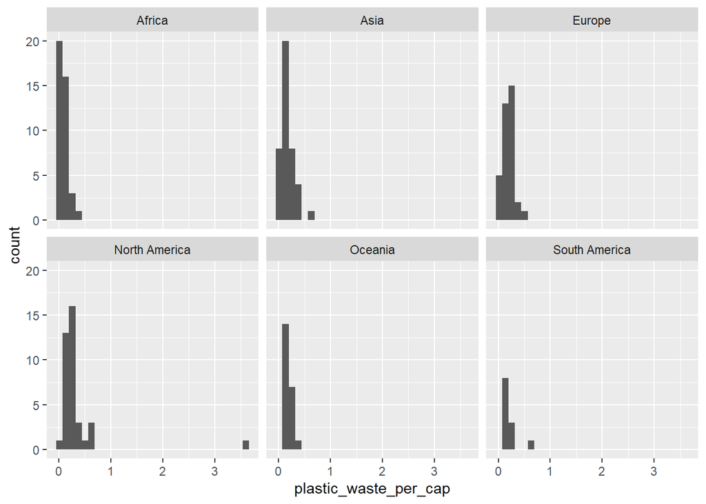

```r
ggplot(data=plastic_waste, aes(x=plastic_waste_per_cap))+
  geom_histogram()+
  facet_wrap(~ continent)
```

Một cách khác để trực quan hóa dữ liệu số (numerical data) là sử dụng biểu đồ mật độ (density plot).

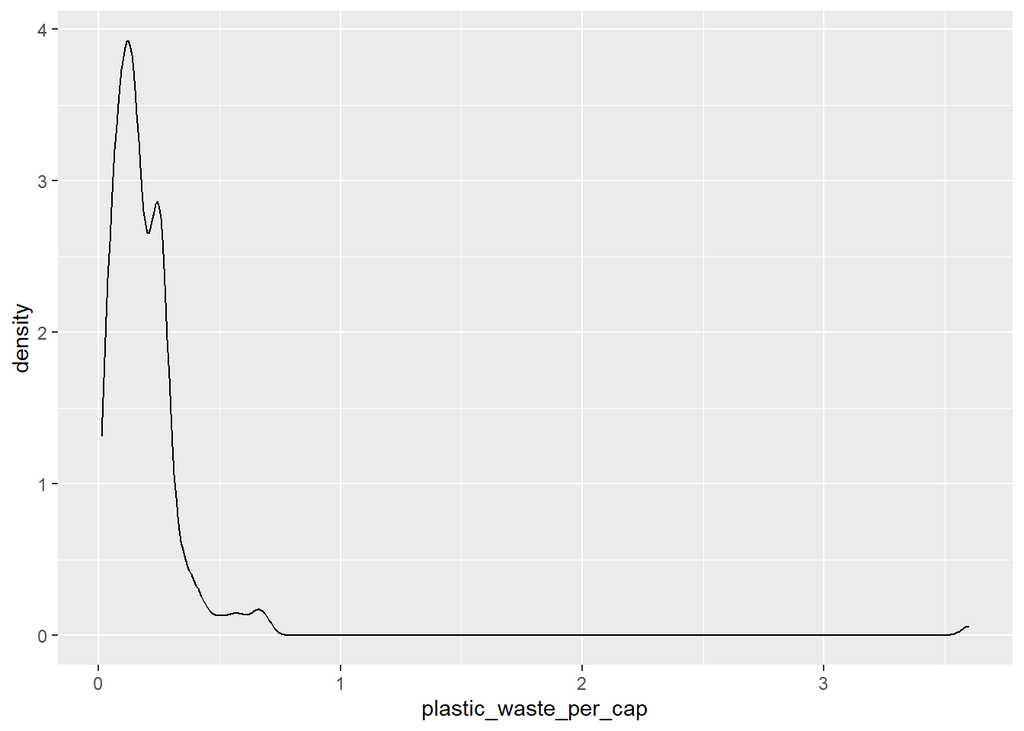

```r
ggplot(data=plastic_waste, aes(x=plastic_waste_per_cap))+
  geom_density ()
```

Ta có thể so sánh sự phân bố giữa các lục địa bằng cách tô màu các đường cong mật độ theo lục địa.

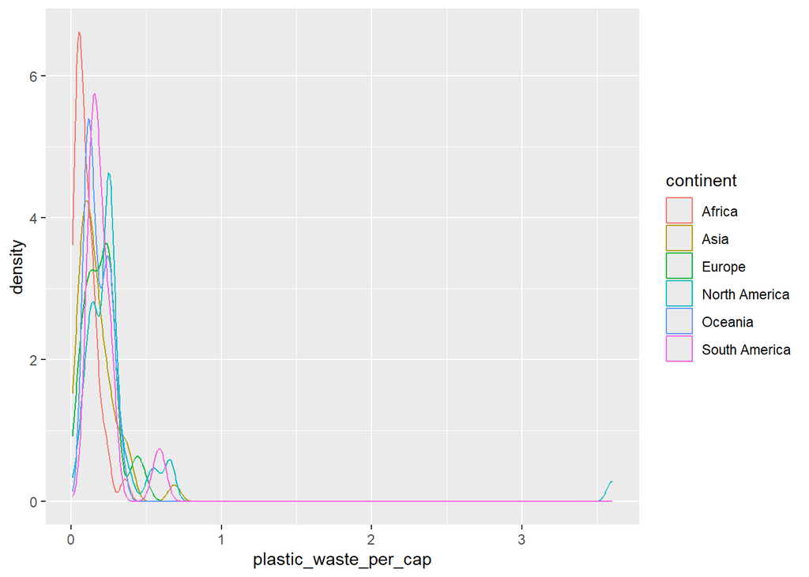

```r
ggplot(data=plastic_waste, aes(x=plastic_waste_per_cap, color=continent))+
  geom_density()
```

Kết quả có thể hơi khó đọc, vì vậy chúng ta cũng hãy tô màu các đường cong bằng màu sắc.

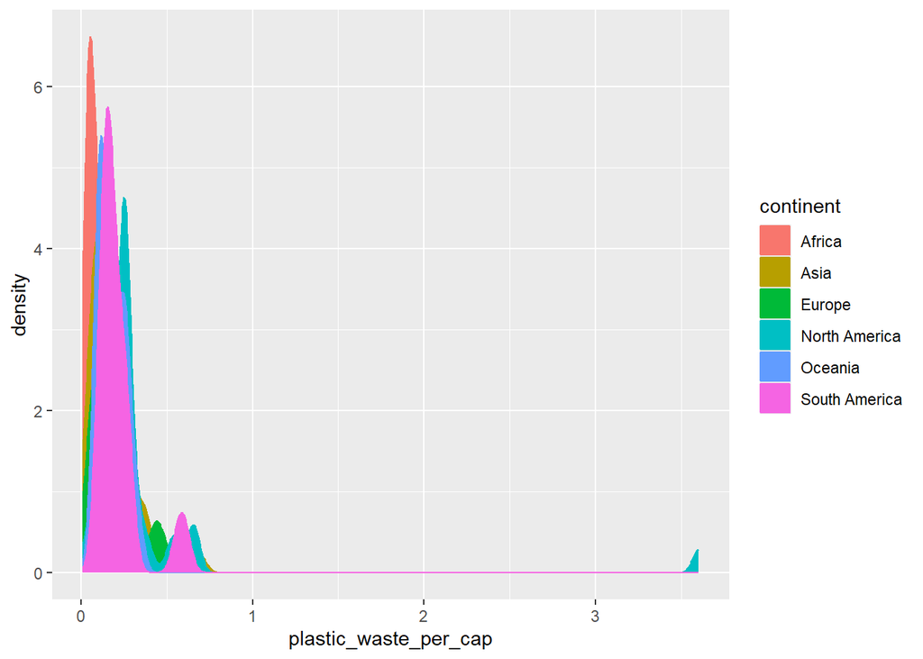

```r
ggplot(data=plastic_waste, aes(x=plastic_waste_per_cap, color=continent, fill=continent))+
  geom_density()
```

Màu sắc chồng chéo lên nhau khiến rất khó để biết điều gì đang xảy ra với sự phân bố ở các lục địa được vẽ trước và do đó bị che phủ bởi các lục địa được vẽ trên chúng. Chúng ta có thể thay đổi mức độ trong suốt của màu tô để giúp thực hiện điều này. Đối số `alpha` nhận các giá trị từ 0 đến 1: 0 là hoàn toàn trong suốt và 1 là hoàn toàn không trong suốt. Không có cách nào để biết giá trị nào sẽ hoạt động tốt nhất, vì vậy bạn chỉ cần thử một vài giá trị.

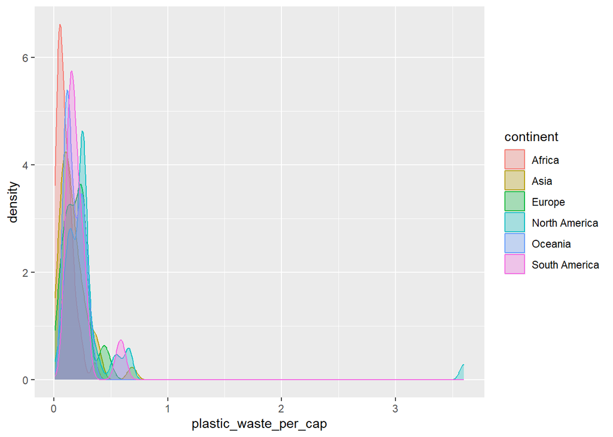

```r
ggplot(data = plastic_waste,
       aes(x = plastic_waste_per_cap,
           color = continent,
           fill = continent)) +
  geom_density(alpha = 0.3)
```

Kết quả có vẻ vẫn không thật sự tốt.

### Câu 2.

Tạo lại các biểu đồ mật độ ở trên bằng cách sử dụng một mức `alpha` khác (thấp hơn) hoạt động tốt hơn để hiển thị các đường cong mật độ cho tất cả các lục địa.

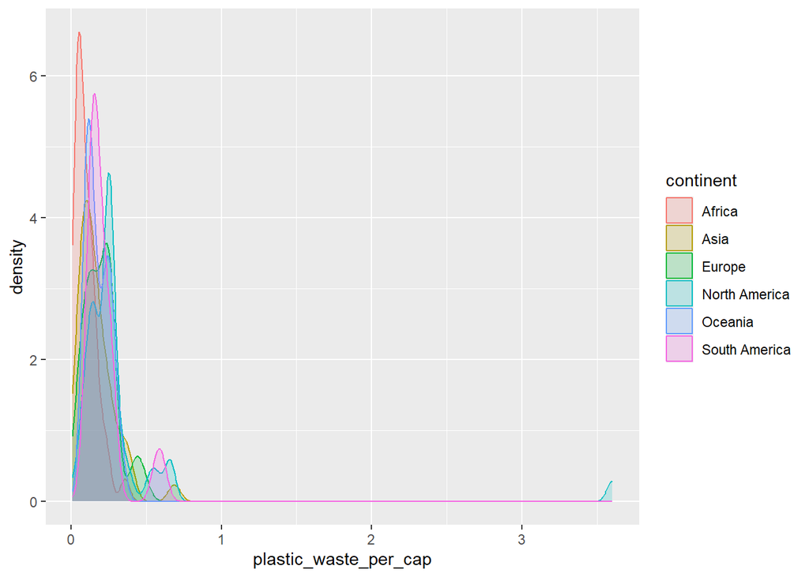

```r
ggplot(data = plastic_waste,
       aes(x = plastic_waste_per_cap,
           color = continent,
           fill = continent)) +
  geom_density(alpha = 0.2)
```

### Câu 3.

Mô tả lý do tại sao, ở biểu đồ trên chúng ta xác định `color` và `fill` của các đường cong bằng cách ánh xạ các thuộc tính thẩm mỹ này trong hàm `ggplot` nhưng lại xác định mức độ `alpha` như một thuộc tính thẩm mỹ trong hàm `geom_density`.

- **Giải thích:**
- Vì gglot được vẽ theo dòng chảy từ đầu tiên là Tidy Data đến Mapping, Geom, Co-Ordinates avs Scales, Lable và Guide. Và theo từng layer chồng lên nhau dưới cùng là Data kế đến là Aesthetic mappings, Geoms and Stats, Coordinates and Scales, Guide, Themes.
- Nếu để thuộc tính “alpha” là hàm thể hiện độ trong suốt nêu để trong hàm “gglot” sẽ bị hàm “geom_density” phủ lên một lớp sẽ ảnh hưởng đến độ trong suốt và ra kết quả không mong đợi.

Một cách khác để hình dung mối quan hệ trên là sử dụng các biểu đồ hộp cạnh nhau (side-by-side boxplots).

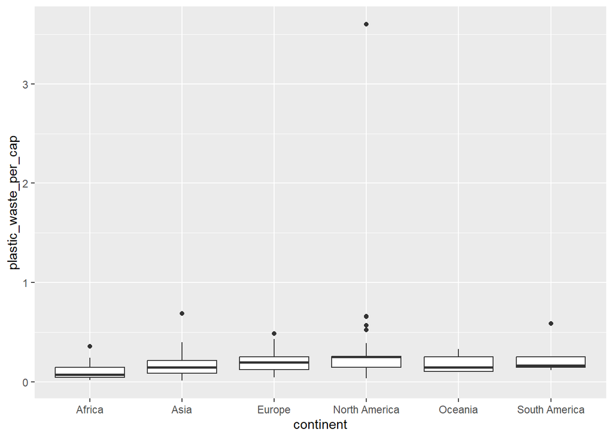

```r
ggplot(data=plastic_waste, aes(x=continent,y=plastic_waste_per_cap))+
  geom_boxplot()
```

### Câu 4.

Chuyển đổi các biểu đồ hộp cạnh nhau (side-by-side boxplots) ở trên thành các [violin plot](http://ggplot2.tidyverse.org/reference/geom_violin.html).Điều gì làm cho các violin plot mô tả được những điều mà các boxplot không thể? Những đặc điểm nào rõ ràng ở các boxplot nhưng không rõ ở violin plot?

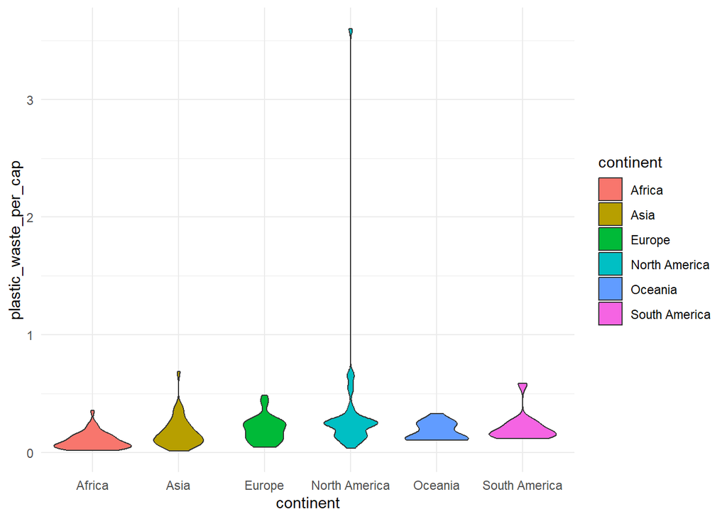

```r
ggplot(data = plastic_waste,
       aes(x = continent,
           y = plastic_waste_per_cap,
           fill = continent)) +
  geom_violin() +
  theme_minimal()
```

- Những điều làm cho các violin plot mô tả được những điều mà các boxplot không thể?
  - Là sự pha trộn của geom_boxplot () và geom_density () nên Violin geom_violin thể hiện density còn boxplot thì không
- Những đặc điểm rõ ràng ở các boxplot nhưng không rõ ở violin plot?
  - Boxplots cũng được sử dụng để phát hiện các ngoại lệ dễ dàng và nhanh chóng (mean sẽ bị lệch so với bình thường)

### Câu 5.

Trực quan hóa mối quan hệ giữa rác thải nhựa trên đầu người và rác thải nhựa được quản lý kém trên đầu người bằng một biểu đồ scatterplot. Mô tả mối quan hệ này.

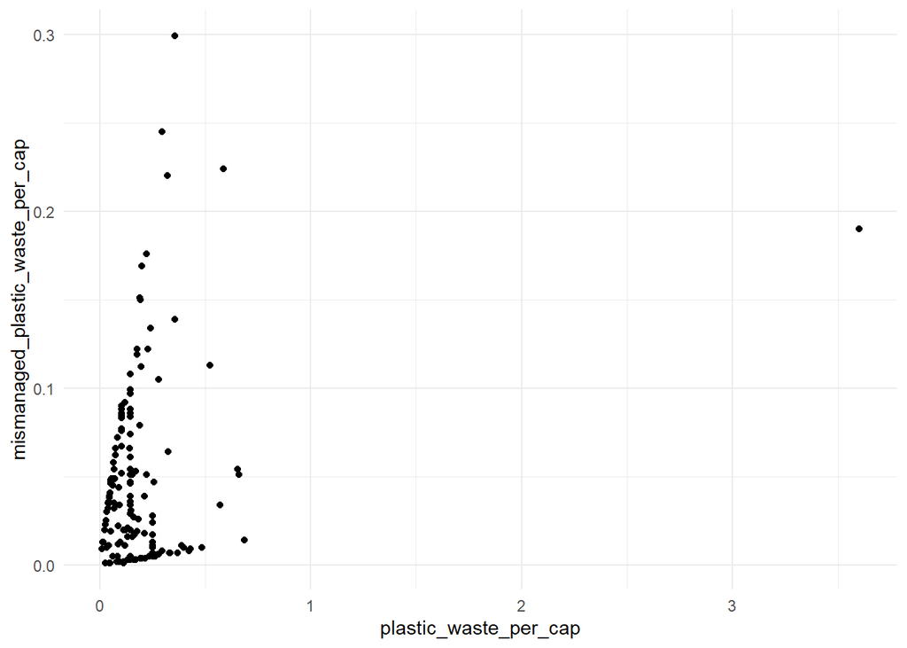

```r
ggplot(data=plastic_waste, aes(x=plastic_waste_per_cap,y=mismanaged_plastic_waste_per_cap))+
  geom_point()+
  theme_minimal()
```

- Khó nhận biết được khu vực nào, khó phân được sự tương quan giữa 2 biến độc lập

### Câu 6.

Tô màu các điểm trong biểu đồ scatterplot theo lục địa. Có sự khác biệt rõ ràng nào giữa các châu lục về mối liên hệ giữa chất thải nhựa trên đầu người và chất thải nhựa được quản lý kém trên đầu người?

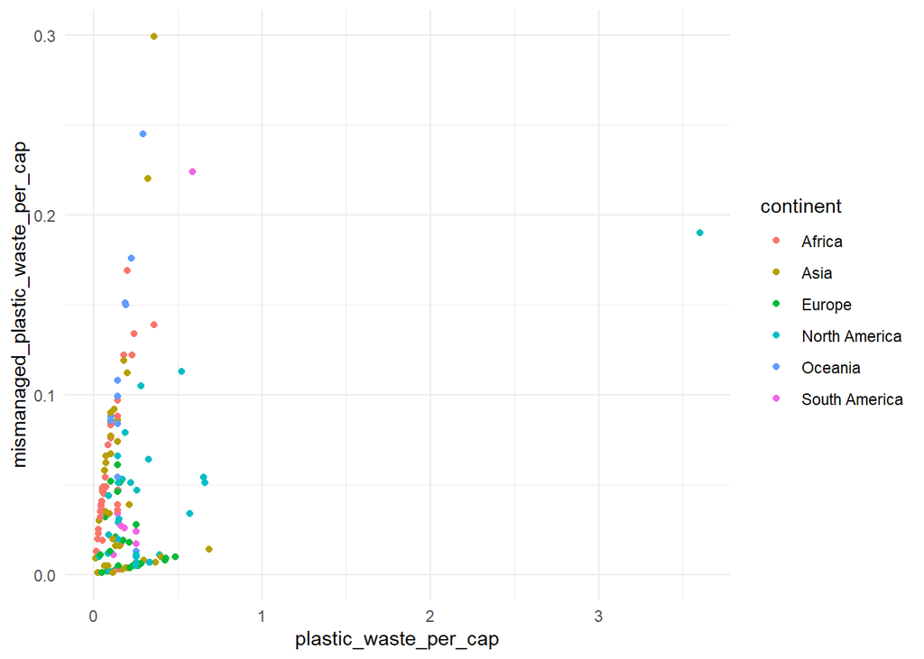

```r
ggplot(data = plastic_waste,
       aes(x = plastic_waste_per_cap,
           y = mismanaged_plastic_waste_per_cap,
           color = continent)) +
  geom_point() +
  theme_minimal()
```

**Nhận xét:** Viết nhận xét của bạn ở đây - Phân biệt được từng khu vực, thển hiện rõ sự tương qua giữa 2 biến đọc lập plastic_waste_per_cap và mismanaged_plastic_waste_per_cap